# modeling2: Flexible models for classification

Sebastian Sauer

2016-09-29 22:45:02

Load libraries, define overhead variables.

```r
library(gridExtra)
library(broom)
library(compute.es)
library(corrr)
library(purrr)
library(doMC)  # multiple cores
library(pscl)  # pseudo R^2
library(magrittr) # piping
library(mice)  # imputation
library(testthat)
library(readr) # csv import
library(knitr) # rmarkdown
library(tidyr) # tibbling objects
library(caret) # modeling
library(ggplot2) # plotting
library(tibble) # tibble
library(dplyr) # data wrangling
library(glmnet)


# results/ variables
mod_results <- list()


# overhead
write_to_file <- FALSE
recompute <- FALSE
test_it <- FALSE
registerDoMC(cores = 4)


# project wd
```

Define paths (data, code, output, etc.).

```r
# PROJHOME that's the project home folder; same as R Project working dir


#paths_file <- file.path(PROJHOME, "analysis/functions", "paths.R")  # for knitr

source("analysis/functions/paths.R")
```

Read data.

```r
data_class <- read_csv("raw_data/data_mod3.csv")

load(file = "analysis/mod_results.Rda")
```

Prepare data (eg., change 0-1 numeric to factor…)

```r
# helper function: check if vector is binary (ie 0 and 1 values only)
is_binary <- function(var){
  return(all(var %in% c(0,1)))
}


if ("ID" %in% names(data_class)) data_class <- data_class %>% select(-ID)


# change strange factor levels to well-behaved ones
if ("contact" %in% names(data_class)) data_class$contact <- dplyr::recode_factor(data_class$contact, `Self-referral` = "0", `CAMHS referral` = "1")


data_class$responder_3m_f <- factor(data_class$responder_3m_f, labels = c("negative", "positive"))




data_class %>%
  mutate_if(is_binary, factor) -> data_class
```

Load function “save_results.Rdm”

```r
save_model_results <- function(obj,
                               test_df = test_sample,
                               predict_results = TRUE,
                               report_varimp = TRUE,
                               fit_pred = "none",
                               conf_matrix = "none"){

  results <- list()

  results$fit <- obj
  results$name <- deparse(substitute(obj))


  if (predict_results == TRUE){
    message("Computing predictiong. Predicted values are: \n")
    fit_pred <- predict(obj, test_df)

    print(fit_pred)

    if (conf_matrix != "none"){
      message("confusion matrix for predicted values and factual values: \n")
      results$confusion_matrix <- confusionMatrix(data = fit_pred, test_df$responder_3m_f)
      print(results$confusion_matrix)
    }
  }

  if (report_varimp == TRUE){
    results$varimp <- varImp(obj, scale = FALSE)
    print(results$varimp)
  }

  if (fit_pred != "none") {
    message("prediction object saved to results list.")
    results$prediction_results <- fit_pred

  } else {
    message("prediction object not found.")
  }


   if (exists("conf_matrix") & (conf_matrix != "none")) {
    message("confusion matrix object saved to results list.")
    results$confusion_matrix <- conf_matrix

  } else {
    message("prediction object not found.")
  }


  return(results)
}
```

# 1 Upfront work

Before I forget: we need to exclude the metric outcome variable `CYBOCS_3m`.

```r
exclude_metric_outcome <- function(data_df = data_class){
  if ("CYBOCS_3m" %in% names(data_df)) {
    data_df <- dplyr::select(data_df, -CYBOCS_3m)
    message("CYBOCS_3m has been excluded from the data set\n")
  }else {
   message("CYBOCS_3m was not in data frame")
  }
  return(data_df)
}

data_class <- exclude_metric_outcome(data_class)
```

Now, let’s split up the data in a test sample and a training sample.

```r
test_split_data <- function(data_df = data_class){
  cat("Class of DV:\n")
  print(str(data_df$responder_3m_f))
  print(str(data_df$responder_3m_f))
  print(str(data_df$responder_3m_f))


  if ("CYBOCS_3m" %in% names(data_df)) warning("CYBOCS_3m is *in* test sample")
  if (!("CYBOCS_3m" %in% names(data_df))) message("CYBOCS_3m is NOT in test sample")
  message("done")
}

test_split_data(data_class)
```

```
## Class of DV:
##  Factor w/ 2 levels "negative","positive": 2 1 1 1 1 1 2 2 1 2 ...
## NULL
##  Factor w/ 2 levels "negative","positive": 2 1 1 1 1 1 2 2 1 2 ...
## NULL
##  Factor w/ 2 levels "negative","positive": 2 1 1 1 1 1 2 2 1 2 ...
## NULL
```

```r
set.seed(42)
trainIndex <- createDataPartition(data_class$responder_3m_f, p = .8,
                                  list = FALSE,
                                  times = 1)

train_sample <- data_class[trainIndex, ]
test_sample <- data_class[-trainIndex, ]

if (test_it ==  TRUE) test_split_data()


predictor_names <- names(train_sample)[names(train_sample) != "responder_3m_f"]
outcome_name <- "responder_3m_f"
```

# 2 Lasso 80/20

A “Lasso” is linear model where model coefficients are penalized in order to shrunk them. That’s a way to keep a model simple (few predictors). The lasso is one model with often performs well at the same time keeping the advantages of typical linear model.

We also compute a cross validation (with default values, ie. 10 folds). Alpha ist set to 1, to prevent ridge regression (see glmnet help for details).

The sample was split in a .8 train sample, and a .2 test sample (hence 80/20).

```r
# start easy

# data_df <- train_sample


data_mm <- model.matrix(responder_3m_f ~ ., data = data_class)

data_mm <- data_mm[, -1]  #exclude intercept as glmnet demeans the data and reports intercept by default: http://stats.stackexchange.com/questions/99546/2-intercept-cooficients-in-glmnet-output

set.seed(42)
trainIndex <- createDataPartition(data_class$responder_3m_f, p = .8,
                                  list = FALSE,
                                  times = 1)

train_mm <- data_mm[trainIndex, ]
test_mm <- data_mm[-trainIndex, ]
train_sample <- data_class[trainIndex, ]
test_sample <- data_class[-trainIndex, ]


test_y_relevel <- relevel(test_sample$responder_3m_f, ref  = "1")
train_y_relevel <- relevel(train_sample$responder_3m_f, ref  = "1")



lasso_cv <- glmnet::cv.glmnet(x = train_mm,
                        y = train_y_relevel,
                        family = "binomial",
                        alpha = 1)
```

Now, let’s check the results.

```r
summary(lasso_cv)
```

```
##            Length Class  Mode
## lambda     85     -none- numeric
## cvm        85     -none- numeric
## cvsd       85     -none- numeric
## cvup       85     -none- numeric
## cvlo       85     -none- numeric
## nzero      85     -none- numeric
## name        1     -none- character
## glmnet.fit 13     lognet list
## lambda.min  1     -none- numeric
## lambda.1se  1     -none- numeric
```

```r
print(lasso_cv)
```

```
## $lambda
##  [1] 1.764224e-01 1.607495e-01 1.464690e-01 1.334571e-01 1.216011e-01
##  [6] 1.107984e-01 1.009554e-01 9.198679e-02 8.381494e-02 7.636905e-02
## [11] 6.958463e-02 6.340293e-02 5.777038e-02 5.263822e-02 4.796199e-02
## [16] 4.370118e-02 3.981888e-02 3.628148e-02 3.305834e-02 3.012153e-02
## [21] 2.744561e-02 2.500742e-02 2.278583e-02 2.076160e-02 1.891720e-02
## [26] 1.723664e-02 1.570539e-02 1.431017e-02 1.303889e-02 1.188055e-02
## [31] 1.082512e-02 9.863442e-03 8.987201e-03 8.188803e-03 7.461332e-03
## [36] 6.798488e-03 6.194529e-03 5.644224e-03 5.142807e-03 4.685934e-03
## [41] 4.269649e-03 3.890345e-03 3.544737e-03 3.229833e-03 2.942903e-03
## [46] 2.681464e-03 2.443250e-03 2.226198e-03 2.028429e-03 1.848229e-03
## [51] 1.684037e-03 1.534432e-03 1.398117e-03 1.273913e-03 1.160742e-03
## [56] 1.057625e-03 9.636681e-04 8.780585e-04 8.000542e-04 7.289796e-04
## [61] 6.642190e-04 6.052116e-04 5.514463e-04 5.024573e-04 4.578204e-04
## [66] 4.171489e-04 3.800906e-04 3.463244e-04 3.155579e-04 2.875246e-04
## [71] 2.619817e-04 2.387079e-04 2.175018e-04 1.981795e-04 1.805738e-04
## [76] 1.645321e-04 1.499155e-04 1.365975e-04 1.244625e-04 1.134056e-04
## [81] 1.033310e-04 9.415133e-05 8.578719e-05 7.816609e-05 7.122203e-05
##
## $cvm
##  [1] 1.471884 1.484566 1.488591 1.485610 1.479998 1.482190 1.487704
##  [8] 1.495487 1.504110 1.508182 1.518154 1.531424 1.542480 1.559625
## [15] 1.580003 1.602544 1.637701 1.688237 1.748214 1.814829 1.885381
## [22] 1.961149 2.042933 2.135134 2.256953 2.396224 2.544041 2.697615
## [29] 2.855603 3.019140 3.204572 3.405867 3.596010 3.781899 3.958634
## [36] 4.130131 4.291256 4.442187 4.591122 4.729731 4.870287 4.988623
## [43] 5.106748 5.223392 5.340773 5.460713 5.579975 5.683876 5.778415
## [50] 5.872012 5.965978 6.047674 6.132157 6.218120 6.302777 6.386483
## [57] 6.470956 6.548672 6.621574 6.695394 6.768342 6.842599 6.908248
## [64] 6.969512 7.026392 7.082333 7.136999 7.192876 7.248336 7.304532
## [71] 7.349447 7.393015 7.434220 7.467753 7.501548 7.536176 7.570624
## [78] 7.605151 7.638936 7.673093 7.706654 7.740440 7.774183 7.808011
## [85] 7.842059
##
## $cvsd
##  [1] 0.07923247 0.08377818 0.09057027 0.09978673 0.11115263 0.12496174
##  [7] 0.13887284 0.15179018 0.16547978 0.18081863 0.19891663 0.21834084
## [13] 0.23766817 0.25713421 0.27554401 0.28861599 0.30384995 0.32476927
## [19] 0.34802962 0.37358575 0.40151284 0.43072943 0.46147117 0.49707268
## [25] 0.54300215 0.59188095 0.64123374 0.69073707 0.74050086 0.79124780
```

[output cut: 956 more lines]

```
##
## $nobs
## [1] 46
##
## attr(,"class")
## [1] "lognet" "glmnet"
##
## $lambda.min
## [1] 0.1764224
##
## $lambda.1se
## [1] 0.1764224
##
## attr(,"class")
## [1] "cv.glmnet"
```

For help on the results, use `?cv.glmnet`.

Here, different values for tuning parameter `lambda` are shown (the penalty parameters).

Let’s look at how the error rate develops as a function of `lambda`.

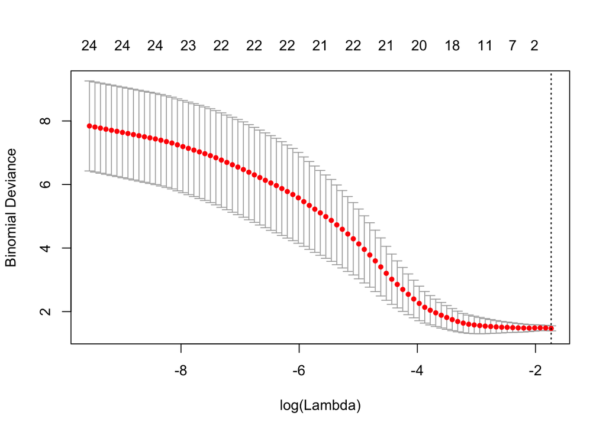

```r
plot(lasso_cv)
```

Ok, so some small log alpha (close to zero) seem appropriate.

For ths best model, let’s look at the shrinked model parameters:

```r
coef(lasso_cv, s = "lambda.min")
```

[output not shown]

Josh! That’s the Null model… No predictor at all was included to the best model. :-/

So, with this alpha-penalty, the model achieved the best prediction: 0.1764224.

Now, let’s test the model, ie., look at the prediciont (hold-out/test sample). We check both the predicted class (0 vs. 1), as well as the estimated probability for each class.

```r
lasso_pred <- predict(lasso_cv, test_mm, s = "lambda.min", type = "response")
lasso_pred
```

```
##            1
## 3  0.5869565
## 9  0.5869565
## 14 0.5869565
## 15 0.5869565
## 17 0.5869565
## 28 0.5869565
## 30 0.5869565
## 40 0.5869565
## 45 0.5869565
## 50 0.5869565
```

```r
lasso_pred <- predict(lasso_cv, test_mm, s = "lambda.min", type = "class")
lasso_pred
```

```
##    1
## 3  "0"
## 9  "0"
## 14 "0"
## 15 "0"
## 17 "0"
## 28 "0"
## 30 "0"
## 40 "0"
## 45 "0"
## 50 "0"
```

Put together in a confusion matrix:

```r
lasso_conf <- confusionMatrix(lasso_pred, test_y_relevel)
lasso_conf
```

```
## Confusion Matrix and Statistics
##
##           Reference
## Prediction 1 0
##          1 0 0
##          0 4 6
##
##                Accuracy : 0.6
##                  95% CI : (0.2624, 0.8784)
##     No Information Rate : 0.6
##     P-Value [Acc > NIR] : 0.6331
##
##                   Kappa : 0
##  Mcnemar's Test P-Value : 0.1336
##
##             Sensitivity : 0.0
##             Specificity : 1.0
##          Pos Pred Value : NaN
##          Neg Pred Value : 0.6
##              Prevalence : 0.4
##          Detection Rate : 0.0
##    Detection Prevalence : 0.0
##       Balanced Accuracy : 0.5
##
##        'Positive' Class : 1
##
```

```r
#debug(save_model_results)
mod_results$lasso <- save_model_results(obj = lasso_cv,
                                        test_df = test_mm,
                                        predict_results = FALSE,
                                        report_varimp = FALSE,
                                        fit_pred = lasso_pred,
                                        conf_matrix = lasso_conf)
```

Unfortunately, the restuls tell us that the model did not find anything. None of the predictors was estimated to play any role.

## 2.1 Lasso 60/40

Let’s compute the Lasso again but increase the test sample. 20% test sample amounts to 10 observations only. One could speculate that is is too few for numeric stability.

```r
set.seed(42)
trainIndex_2 <- createDataPartition(data_class$responder_3m_f, p = .6,
                                  list = FALSE,
                                  times = 1)
# length(trainIndex_2)

train_mm_2 <- data_mm[trainIndex_2, ]
test_mm_2 <- data_mm[-trainIndex_2, ]

train_sample_2 <- data_class[trainIndex_2, ]
test_sample_2 <- data_class[-trainIndex_2, ]



lasso_cv_2 <- glmnet::cv.glmnet(x = train_mm_2,
                        y = train_sample_2$responder_3m_f,
                        family = "binomial",
                        alpha = 1)
# str(lasso_cv_2)
```

Now, let’s check the results.

```r
summary(lasso_cv_2)
```

```
##            Length Class  Mode
## lambda     49     -none- numeric
## cvm        49     -none- numeric
## cvsd       49     -none- numeric
## cvup       49     -none- numeric
## cvlo       49     -none- numeric
## nzero      49     -none- numeric
## name        1     -none- character
## glmnet.fit 13     lognet list
## lambda.min  1     -none- numeric
## lambda.1se  1     -none- numeric
```

```r
print(lasso_cv_2)
```

```
## $lambda
##  [1] 0.270617291 0.246576397 0.224671229 0.204712056 0.186526002
##  [6] 0.169955546 0.154857163 0.141100080 0.128565138 0.117143765
## [11] 0.106737036 0.097254812 0.088614962 0.080742653 0.073569699
## [16] 0.067033969 0.061078856 0.055652779 0.050708739 0.046203915
## [21] 0.042099286 0.038359302 0.034951567 0.031846566 0.029017405
## [26] 0.026439579 0.024090759 0.021950603 0.020000572 0.018223776
## [31] 0.016604826 0.015129699 0.013785618 0.012560942 0.011445062
## [36] 0.010428315 0.009501892 0.008657770 0.007888638 0.007187833
## [41] 0.006549286 0.005967465 0.005437332 0.004954294 0.004514168
## [46] 0.004113142 0.003747742 0.003414803 0.003111441
##
## $cvm
##  [1] 1.394076 1.369533 1.353631 1.332978 1.314706 1.305664 1.303119
##  [8] 1.302396 1.307417 1.327941 1.354494 1.390700 1.440220 1.476990
```

[output cut: 148 more lines]

```r
coef(lasso_cv_2, s = "lambda.min")
```

```
## 33 x 1 sparse Matrix of class "dgCMatrix"
##                               1
## (Intercept)          -0.3889822
## CYBOCS_pre_OBS        .
## CYBOCS_pre_COMP       .
## CYBOCS_pre_insight    .
## CYBOCS_pre_avoid      0.5825060
## ChOCI_R_C_sumsym_PRE  .
## ChOCI_R_C_sumimp_PRE  .
## EWSASC_sum_PRE        .
## SCAS_S_C_sum_PRE      .
## CDI_S_sum_PRE         .
## ChOCI_R_P_sumsym_PRE  .
## ChOCI_R_P_sumimp_PRE  .
## FAS_PR_sum_PRE        .
## EWSASP_sum_PRE        .
## SCAS_S_P_sum_PRE      .
## Depression            .
## PanicDisorder         .
## SocialPhob            .
## SpecificPhob          .
## TourettesTics         .
## ADHD                  .
## GAD                   .
## numberdiagnos         .
## sexgirl               .
## age                   .
## contactSelf-referral  .
## distance              .
## medication_yesno      .
## CGI_S_pre             .
## checking              .
## obsessions            .
## contamination         .
## symmetry             -0.2607841
```

Hm, it is not better, even slightly worse.

Now, let’s check predictive accuracy.

```r
lasso_pred_2 <- predict(lasso_cv_2, test_mm_2, s = "lambda.min", type = "response")
lasso_pred_2
```

```
##            1
## 1  0.4831913
## 2  0.4831913
## 3  0.4831913
## 5  0.7498386
## 6  0.6260354
## 8  0.4831913
## 11 0.7498386
## 14 0.3430422
## 15 0.6848238
## 16 0.4831913
## 22 0.3430422
## 24 0.3430422
## 26 0.4831913
## 31 0.4831913
## 35 0.4039623
## 38 0.4039623
## 41 0.5482305
## 43 0.7498386
## 45 0.7498386
## 46 0.6848238
## 50 0.6260354
## 52 0.6260354
```

```r
lasso_pred_2 <- predict(lasso_cv_2, test_mm_2, s = "lambda.min", type = "class")
lasso_pred_2
```

```
##    1
## 1  "negative"
## 2  "negative"
## 3  "negative"
## 5  "positive"
## 6  "positive"
## 8  "negative"
## 11 "positive"
## 14 "negative"
## 15 "positive"
## 16 "negative"
## 22 "negative"
## 24 "negative"
## 26 "negative"
## 31 "negative"
## 35 "negative"
## 38 "negative"
## 41 "positive"
## 43 "positive"
## 45 "positive"
## 46 "positive"
## 50 "positive"
## 52 "positive"
```

Put together in a confusion matrix:

```r
lasso_conf_2 <- confusionMatrix(lasso_pred_2, test_sample_2$responder_3m_f)
lasso_conf_2
```

```
## Confusion Matrix and Statistics
##
##           Reference
## Prediction negative positive
##   negative        4        8
##   positive        5        5
##
##                Accuracy : 0.4091
##                  95% CI : (0.2071, 0.6365)
##     No Information Rate : 0.5909
##     P-Value [Acc > NIR] : 0.9735
##
##                   Kappa : -0.1626
##  Mcnemar's Test P-Value : 0.5791
##
##             Sensitivity : 0.4444
##             Specificity : 0.3846
##          Pos Pred Value : 0.3333
##          Neg Pred Value : 0.5000
##              Prevalence : 0.4091
##          Detection Rate : 0.1818
##    Detection Prevalence : 0.5455
##       Balanced Accuracy : 0.4145
##
##        'Positive' Class : negative
##
```

```r
#debug(save_model_results)
mod_results$lasso_2 <- save_model_results(obj = lasso_cv_2,
                                        test_df = test_mm_2,
                                        predict_results = FALSE,
                                        report_varimp = FALSE,
                                        fit_pred = lasso_pred_2,
                                        conf_matrix = lasso_conf_2)
```

# 3 Random Forest

Hm, let’s look at some completely different model: Random Forests.

We use `mtry` (number of chosen variables) as a tuning parameter. `ntree` was set to 1000 (default is 500).

Assuming 4 cores for computation.

## 3.1 Random Forest 80/20

Let’s split up the sample in 80% training, and 20% testing first, as we did above. Computational somewhat expensive.

```r
grid_rf <- expand.grid(.mtry = c(2, 4, 5, 6, 7, 8, 16))

set.seed(42)
rf1 <- caret::train(responder_3m_f ~ .,
                    data = train_sample,
                    method = "rf",
                    trControl = trainControl(method = "repeatedcv",
                                             number = 10,
                                             repeats = 10),
                    varImp = TRUE,
                    allowParallel = TRUE,
                    metric = "Kappa",
                    ntree = 1000,
                    tuneGrid = grid_rf)
```

Now, let’s check the results.

```r
print(rf1)
```

```
## Random Forest
##
## 46 samples
## 32 predictors
##  2 classes: '0', '1'
##
## No pre-processing
## Resampling: Cross-Validated (10 fold, repeated 10 times)
## Summary of sample sizes: 42, 42, 42, 41, 41, 41, ...
## Resampling results across tuning parameters:
##
##   mtry  Accuracy   Kappa
##    2    0.5480000  -0.02053613
##    4    0.5700000   0.05066434
##    5    0.5698333   0.06073427
##    6    0.5685000   0.05304362
##    7    0.5653333   0.04758741
##    8    0.5713333   0.07424409
##   16    0.5838333   0.10046620
##
## Kappa was used to select the optimal model using  the largest value.
## The final value used for the model was mtry = 16.
```

```r
print(rf1$finalModel)
```

```
##
## Call:
##  randomForest(x = x, y = y, ntree = 1000, mtry = param$mtry, varImp = TRUE,      allowParallel = TRUE)
##                Type of random forest: classification
##                      Number of trees: 1000
## No. of variables tried at each split: 16
##
##         OOB estimate of  error rate: 47.83%
## Confusion matrix:
##    0 1 class.error
## 0 20 7   0.2592593
## 1 15 4   0.7894737
```

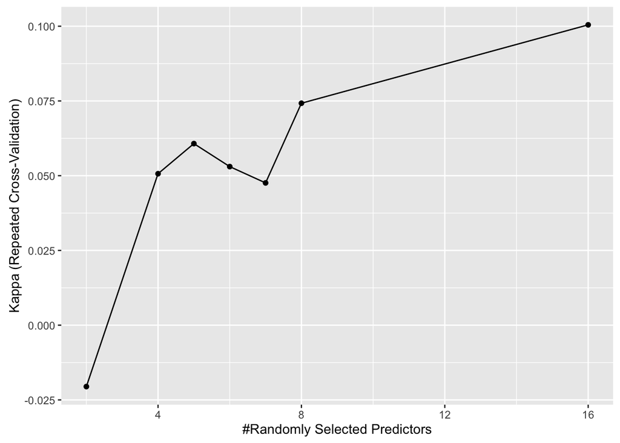

```r
ggplot(rf1)
```

Now let’s test the model on the hold-out sample:

```r
rf1_predict <- predict(rf1, test_sample, type = "raw")
rf1_predict
```

```
##  [1] 1 1 1 0 0 1 0 1 1 0
## Levels: 0 1
```

```r
rf1_conf_m <- confusionMatrix(rf1_predict, test_sample$responder_3m_f)
rf1_conf_m
```

```
## Confusion Matrix and Statistics
##
##           Reference
## Prediction 0 1
##          0 2 2
##          1 4 2
##
##                Accuracy : 0.4
##                  95% CI : (0.1216, 0.7376)
##     No Information Rate : 0.6
##     P-Value [Acc > NIR] : 0.9452
##
##                   Kappa : -0.1538
##  Mcnemar's Test P-Value : 0.6831
##
##             Sensitivity : 0.3333
##             Specificity : 0.5000
##          Pos Pred Value : 0.5000
##          Neg Pred Value : 0.3333
##              Prevalence : 0.6000
##          Detection Rate : 0.2000
##    Detection Prevalence : 0.4000
##       Balanced Accuracy : 0.4167
##
##        'Positive' Class : 0
##
```

What about the variable importance:

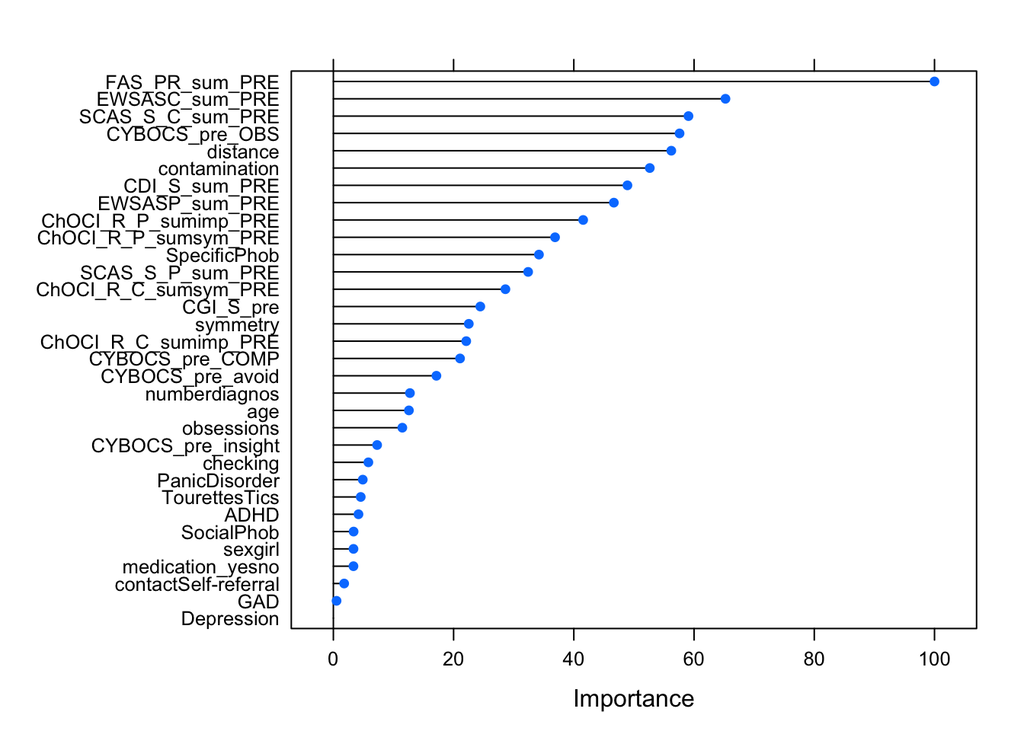

```r
plot(varImp(rf1))
```

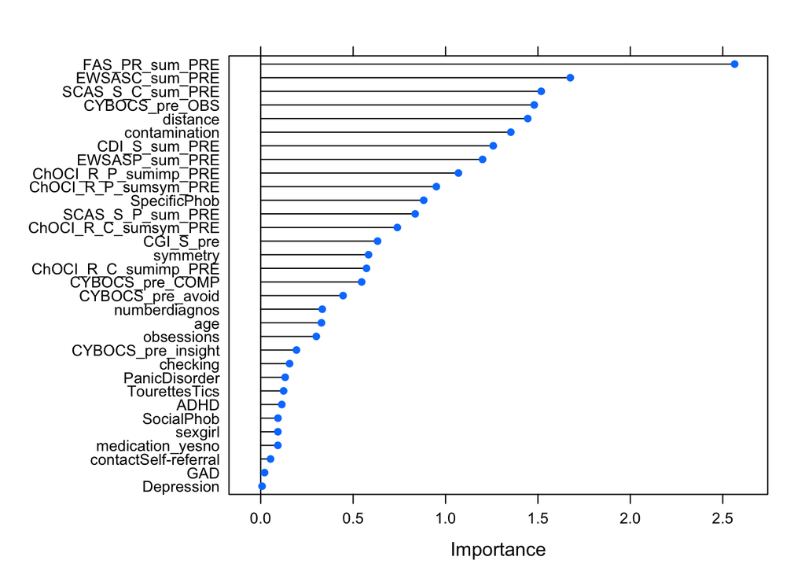

```r
plot(varImp(rf1, scale = FALSE))
```

Note that the varImp values are scaled relatively in the first output; ie., the most important variable has value of 100. In the second output, the mean decrease in predictive accuracy is given, when the variable would be randomly permutated (ie., broken). Note that varImp is based on cross validated training data.

Hm, looks not good. True test values for prediction are: 1, 1, 0, 1, 1, 0, 0, 0, 0, 0.

However, it was predicted that 1, 1, 1, 0, 0, 1, 0, 1, 1, 0.

Worse than chance… Can that be? Strange.

```r
mod_results$rf1 <- save_model_results(obj = rf1,
                                        test_df = test_sample,
                                        predict_results = FALSE,
                                        report_varimp = FALSE,
                                        fit_pred = rf1_predict,
                                        conf_matrix = rf1_conf_m)
```

## 3.2 Random Forest 60/40

Now the same with a 60-40 sample split up.

```r
set.seed(42)
rf2 <- caret::train(responder_3m_f ~ .,
                    data = train_sample_2,
                    method = "rf",
                    trControl = trainControl(method = "repeatedcv",
                                             number = 10,
                                             repeats = 10),
                    varImp = TRUE,
                    allowParallel = TRUE,
                    metric = "Kappa",
                    ntree = 1000,
                    tuneGrid = grid_rf)
```

Now, let’s check the results.

```r
print(rf2)
```

```
## Random Forest
##
## 34 samples
## 42 predictors
##  2 classes: 'negative', 'positive'
##
## No pre-processing
## Resampling: Cross-Validated (10 fold, repeated 10 times)
## Summary of sample sizes: 31, 31, 30, 31, 31, 30, ...
## Resampling results across tuning parameters:
##
##   mtry  Accuracy   Kappa
##    2    0.7025000  0.305
##    4    0.7133333  0.351
##    5    0.6950000  0.320
##    6    0.6841667  0.307
##    7    0.6750000  0.286
##    8    0.6841667  0.300
##   16    0.6616667  0.270
##
## Kappa was used to select the optimal model using  the largest value.
## The final value used for the model was mtry = 4.
```

```r
print(rf2$finalModel)
```

```
##
## Call:
##  randomForest(x = x, y = y, ntree = 1000, mtry = param$mtry, varImp = TRUE,      allowParallel = TRUE)
##                Type of random forest: classification
##                      Number of trees: 1000
## No. of variables tried at each split: 4
##
##         OOB estimate of  error rate: 32.35%
## Confusion matrix:
##          negative positive class.error
## negative        6        8   0.5714286
## positive        3       17   0.1500000
```

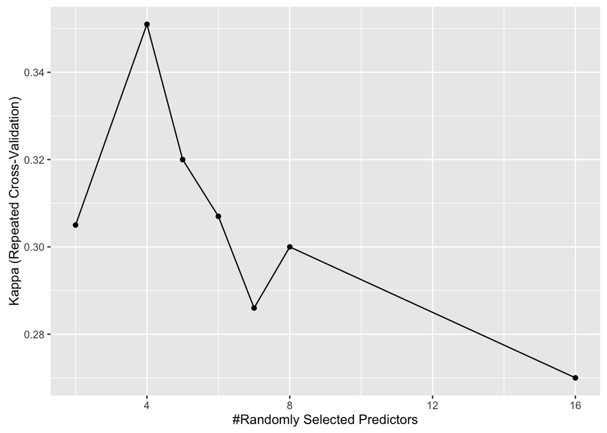

```r
ggplot(rf2)
```

Now let’s test the model on the hold-out sample:

```r
rf2_predict <- predict(rf2, test_sample_2, type = "raw")
rf2_predict
```

```
##  [1] negative positive negative positive negative positive positive
##  [8] negative positive negative positive negative positive negative
## [15] negative positive positive positive positive positive positive
## [22] positive
## Levels: negative positive
```

```r
rf2_conf_m <- confusionMatrix(rf2_predict, test_sample_2$responder_3m_f)
rf2_conf_m
```

```
## Confusion Matrix and Statistics
##
##           Reference
## Prediction negative positive
##   negative        3        5
##   positive        6        8
##
##                Accuracy : 0.5
##                  95% CI : (0.2822, 0.7178)
##     No Information Rate : 0.5909
##     P-Value [Acc > NIR] : 0.8605
##
##                   Kappa : -0.0522
##  Mcnemar's Test P-Value : 1.0000
##
##             Sensitivity : 0.3333
##             Specificity : 0.6154
##          Pos Pred Value : 0.3750
##          Neg Pred Value : 0.5714
##              Prevalence : 0.4091
##          Detection Rate : 0.1364
##    Detection Prevalence : 0.3636
##       Balanced Accuracy : 0.4744
##
##        'Positive' Class : negative
##
```

Unfortunately, not convincing at all.

What about the variable importance:

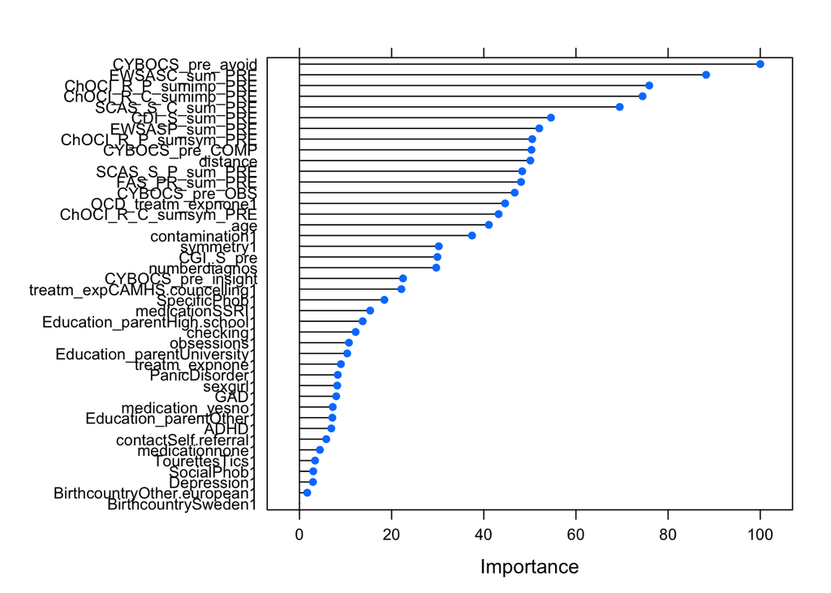

```r
plot(varImp(rf2))
```

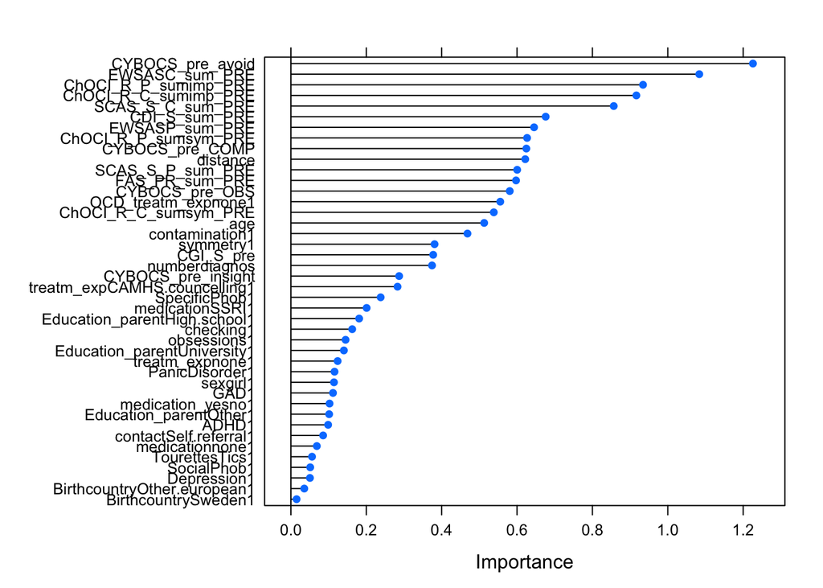

```r
plot(varImp(rf2, scale = FALSE))
```

```r
mod_results$rf2 <- save_model_results(obj = rf2,
                                        test_df = test_sample_2,
                                        predict_results = FALSE,
                                        report_varimp = FALSE,
                                        fit_pred = rf2_predict,
                                        conf_matrix = rf2_conf_m)
```

# 4 Support Vector Machines (SVM)

SVM are another algorithm, quite different to the previous ones. Let’s see what happens.

We use a radial kernel and rely on defaults for the rest.

Again, 10/10 repeated cv. Accuracy metric is again Kappa.

## 4.1 SVM Radial 80/20

```r
outcome_train <- dplyr::recode(train_sample$responder_3m_f, `0` = "no", `1` = "yes")
outcome_test <- dplyr::recode(test_sample$responder_3m_f, `0` = "no", `1` = "yes")



mycontrol <- trainControl(method = "repeatedcv",
                          number = 10,
                          repeats = 10,
                          classProbs = TRUE)

set.seed(42)
svm1 <- caret::train(x = train_mm,
                     y = outcome_train,
                     method = "svmRadial",
                     trControl = mycontrol,
                     varImp = TRUE,
                     allowParallel = TRUE,
                     tuneLength = 9,
                     metric = "Kappa",
                     allowParallel = TRUE,
                     preProcess = c("center", "scale")
                   )
```

Resulting in:

```r
print(svm1)
```

```
## Support Vector Machines with Radial Basis Function Kernel
##
## 46 samples
## 32 predictors
##  2 classes: 'no', 'yes'
##
## Pre-processing: centered (32), scaled (32)
## Resampling: Cross-Validated (10 fold, repeated 10 times)
## Summary of sample sizes: 42, 42, 42, 41, 41, 41, ...
## Resampling results across tuning parameters:
##
##   C      Accuracy   Kappa
##    0.25  0.5716667   0.04929937
##    0.50  0.5496667   0.03182184
##    1.00  0.5700000   0.07241026
##    2.00  0.5711667   0.03483849
##    4.00  0.5408333  -0.02554779
##    8.00  0.5893333   0.07775225
##   16.00  0.5698333   0.04424742
##   32.00  0.5930000   0.08453713
##   64.00  0.5650000   0.01946886
##
## Tuning parameter 'sigma' was held constant at a value of 0.02098991
## Kappa was used to select the optimal model using  the largest value.
## The final values used for the model were sigma = 0.02098991 and C = 32.
```

```r
print(svm1$finalModel)
```

```
## Support Vector Machine object of class "ksvm"
##
## SV type: C-svc  (classification)
##  parameter : cost C = 32
##
## Gaussian Radial Basis kernel function.
##  Hyperparameter : sigma =  0.0209899054765562
##
## Number of Support Vectors : 41
##
## Objective Function Value : -51.9658
## Training error : 0
## Probability model included.
```

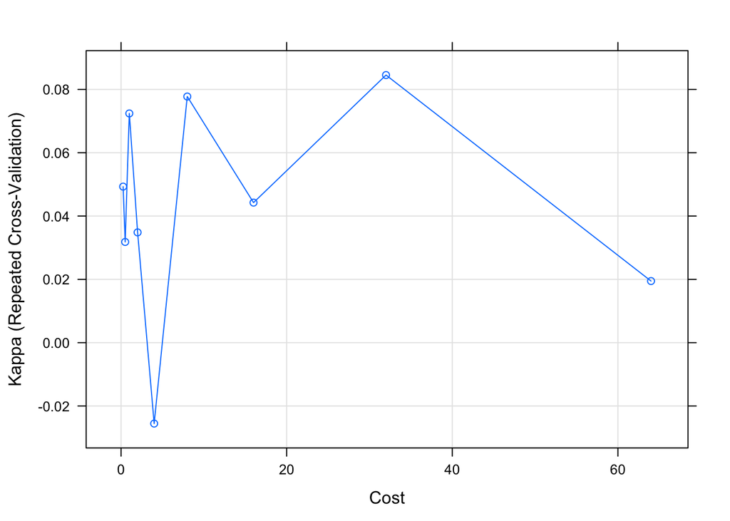

```r
plot(svm1)
```

Saving, training error was zero…

Predicting test sample:

```r
svm1_predict <- predict(svm1, test_mm)
svm1_predict
```

```
##  [1] yes yes yes yes yes yes yes yes no  no
## Levels: no yes
```

And truth is 1, 1, 0, 1, 1, 0, 0, 0, 0, 0.

Confusion matrix:

```r
svm1_conf_m <- confusionMatrix(svm1_predict, outcome_test)
svm1_conf_m
```

```
## Confusion Matrix and Statistics
##
##           Reference
## Prediction no yes
##        no   2   0
##        yes  4   4
##
##                Accuracy : 0.6
##                  95% CI : (0.2624, 0.8784)
##     No Information Rate : 0.6
##     P-Value [Acc > NIR] : 0.6331
##
##                   Kappa : 0.2857
##  Mcnemar's Test P-Value : 0.1336
##
##             Sensitivity : 0.3333
##             Specificity : 1.0000
##          Pos Pred Value : 1.0000
##          Neg Pred Value : 0.5000
##              Prevalence : 0.6000
##          Detection Rate : 0.2000
##    Detection Prevalence : 0.2000
##       Balanced Accuracy : 0.6667
##
##        'Positive' Class : no
##
```

Not very convincing unfortunately…

Variable Importance: Note that SVM do not have an intrinsic varImp algorithm. Instead, ROC values are used.

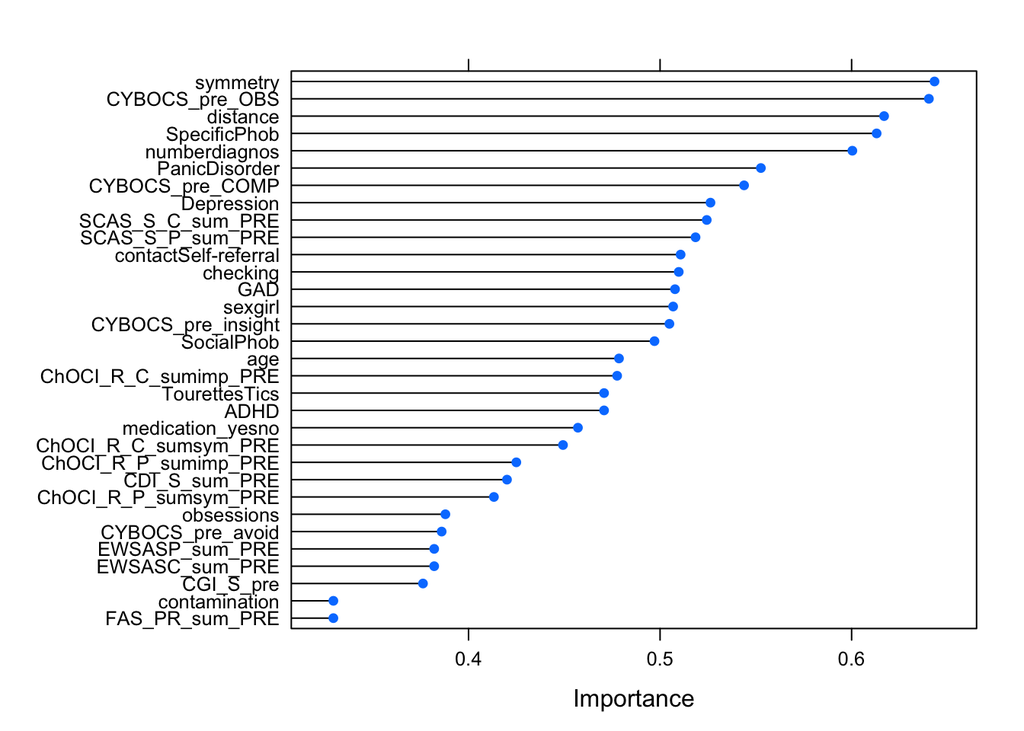

```r
svm1_varImp <- caret::varImp(svm1, scale = FALSE)
plot(svm1_varImp)
```

```r
mod_results$svm_1 <- save_model_results(obj = svm1,
                                        test_df = test_sample,
                                        predict_results = FALSE,
                                        report_varimp = FALSE,
                                        fit_pred = svm1_predict,
                                        conf_matrix = svm1_conf_m)
```

## 4.2 SVM Radial, 60-40

```r
outcome_train_2 <- dplyr::recode(train_sample_2$responder_3m_f, `0` = "no", `1` = "yes")
outcome_test_2 <- dplyr::recode(test_sample_2$responder_3m_f, `0` = "no", `1` = "yes")



mycontrol <- trainControl(method = "repeatedcv",
                          number = 10,
                          repeats = 10,
                          classProbs = TRUE)

set.seed(42)
svm_2 <- caret::train(x = train_mm_2,
                     y = outcome_train_2,
                     method = "svmRadial",
                     trControl = mycontrol,
                     varImp = TRUE,
                     allowParallel = TRUE,
                     tuneLength = 9,
                     metric = "Kappa",
                     allowParallel = TRUE,
                     preProcess = c("center", "scale")
                   )
```

Resulting in:

```r
print(svm_2)
```

```
## Support Vector Machines with Radial Basis Function Kernel
##
## 34 samples
## 32 predictors
##  2 classes: 'negative', 'positive'
##
## Pre-processing: centered (32), scaled (32)
## Resampling: Cross-Validated (10 fold, repeated 10 times)
## Summary of sample sizes: 31, 31, 30, 31, 31, 30, ...
## Resampling results across tuning parameters:
##
##   C      Accuracy   Kappa
##    0.25  0.6391667  0.236
##    0.50  0.6258333  0.200
##    1.00  0.6125000  0.175
##    2.00  0.6816667  0.333
##    4.00  0.6616667  0.299
##    8.00  0.6858333  0.341
##   16.00  0.6883333  0.326
##   32.00  0.6991667  0.350
##   64.00  0.6841667  0.346
##
## Tuning parameter 'sigma' was held constant at a value of 0.01999122
## Kappa was used to select the optimal model using  the largest value.
## The final values used for the model were sigma = 0.01999122 and C = 32.
```

```r
print(svm_2$finalModel)
```

```
## Support Vector Machine object of class "ksvm"
##
## SV type: C-svc  (classification)
##  parameter : cost C = 32
##
## Gaussian Radial Basis kernel function.
##  Hyperparameter : sigma =  0.0199912164421775
##
## Number of Support Vectors : 31
##
## Objective Function Value : -27.9921
## Training error : 0
## Probability model included.
```

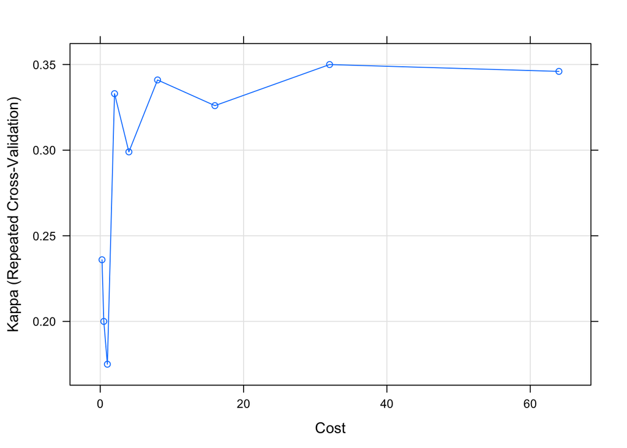

```r
plot(svm_2)
```

Training error was zero…

Predicting test sample:

```r
svm_2_predict <- predict(svm_2, test_mm_2)
svm_2_predict
```

```
##  [1] negative positive negative positive positive positive positive
##  [8] negative positive negative negative negative positive negative
## [15] negative positive negative positive positive positive positive
## [22] positive
## Levels: negative positive
```

Confusion matrix:

```r
svm_2_conf_m <- confusionMatrix(svm_2_predict, outcome_test_2)
svm_2_conf_m
```

```
## Confusion Matrix and Statistics
##
##           Reference
## Prediction negative positive
##   negative        3        6
##   positive        6        7
##
##                Accuracy : 0.4545
##                  95% CI : (0.2439, 0.6779)
##     No Information Rate : 0.5909
##     P-Value [Acc > NIR] : 0.9343
##
##                   Kappa : -0.1282
##  Mcnemar's Test P-Value : 1.0000
##
##             Sensitivity : 0.3333
##             Specificity : 0.5385
##          Pos Pred Value : 0.3333
##          Neg Pred Value : 0.5385
##              Prevalence : 0.4091
##          Detection Rate : 0.1364
##    Detection Prevalence : 0.4091
##       Balanced Accuracy : 0.4359
##
##        'Positive' Class : negative
##
```

VarImp:

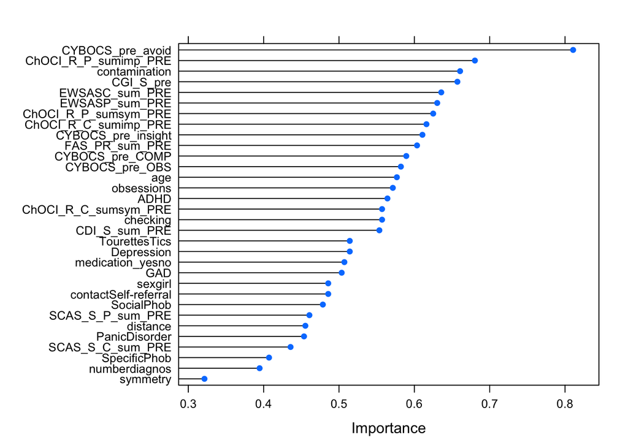

```r
svm_2_varImp <- caret::varImp(svm_2, scale = FALSE)
plot(svm_2_varImp)
```

```r
mod_results$svm_2 <- save_model_results(obj = svm_2,
                                        test_df = test_sample_2,
                                        predict_results = FALSE,
                                        report_varimp = FALSE,
                                        fit_pred = svm_2_predict,
                                        conf_matrix = svm_2_conf_m)
```

# 5 Sense check

As the results were not as (good as) expected, let’s do a sense check.

## 5.1 Compare groups of outcome variable for each numeric predictor

If the outcome variables are expected to exert an influence on the binary outcome, they should separate the groups, right?

Ok, let’s see.

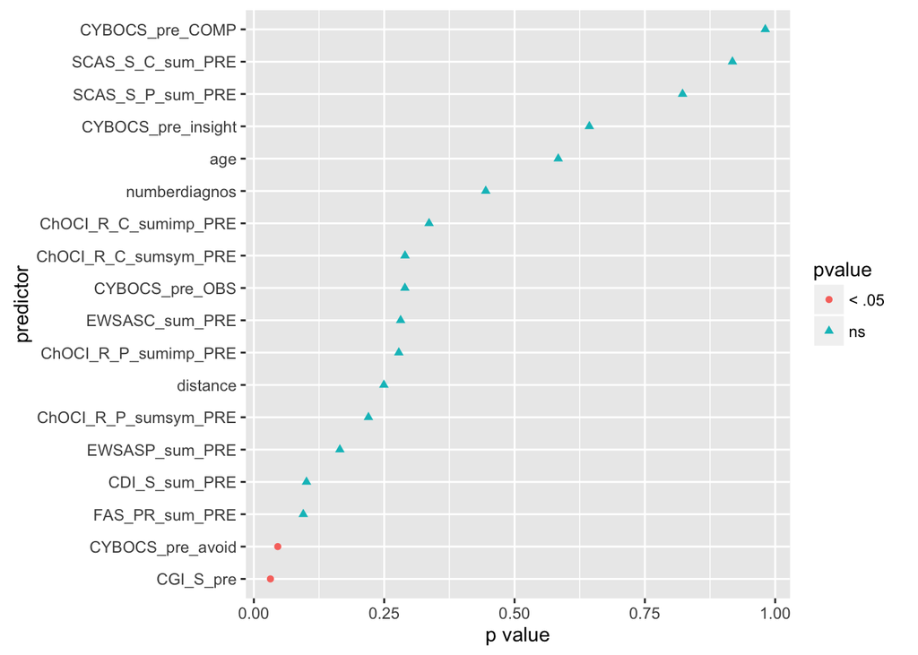

```r
data_class %>%
  select_if(is.numeric) %>% names -> num_preds

data_class %>%
  dplyr::select(one_of(num_preds)) %>%
  na.omit() %>%
  map(~t.test(. ~ data_class$responder_3m_f)$p.value) %>%
  as.data.frame %>%
  gather %>%
  mutate(pvalue = ifelse(value < .05, "< .05", "ns")) %>%
  ggplot(aes(x = reorder(key, value), y = value)) +
  geom_point(aes(color = pvalue, shape = pvalue)) +
  coord_flip() +
  ylab("p value") +
  xlab("predictor") #+
```

```r
  # ggtitle("Differences (t-test p-value) between the two outcome groups")
```

So out of all predictors, it appears that only few are statistically significant. That is, the two outcome groups differ statistically significantly on these values:

```r
data_class %>%
  select(one_of(num_preds)) %>%
  na.omit() %>%
  map(~t.test(. ~ data_class$responder_3m_f)$p.value) %>%
  as.data.frame %>%
  gather %>%
  filter(value <  .05) %>%
  arrange(value)
```

```
##                key      value
## 1        CGI_S_pre 0.03179818
## 2 CYBOCS_pre_avoid 0.04585717
```

Note that no control for multiple testing was undertaken. Interpret with caution.

Maybe better to look for the effect size in each case:

```r
data_class %>%
  select_if(is.numeric) %>% names -> num_preds


data_class %>%
  dplyr::select(one_of(num_preds)) %>%
  # na.omit() %>%
  map(~t.test(. ~ data_class$responder_3m_f)) %>%
  map(~compute.es::tes(.$statistic,
                       n.1 = nrow(dplyr::filter(data_class, responder_3m_f == "negative")),
                       n.2 = nrow(dplyr::filter(data_class, responder_3m_f == "positive")))) %>%
  map(~do.call(rbind, .)) %>%
  as.data.frame %>%
  t %>%
  data.frame %>%
  rownames_to_column %>%
  rename(predictor = rowname) ->
  data_class_effsize
```

[output not shown]

[output cut: 612 more lines]

```
##   p-value(z) = 0.04
##
##  Odds Ratio ES:
##
##  OR [ 95 %CI] = 0.34 [ 0.12 , 0.93 ]
##   p-value(OR) = 0.04
##
##  Log OR [ 95 %CI] = -1.09 [ -2.09 , -0.08 ]
##   var(lOR) = 0.25
##   p-value(Log OR) = 0.04
##
##  Other:
##
##  NNT = -7.99
##  Total N = 56
```

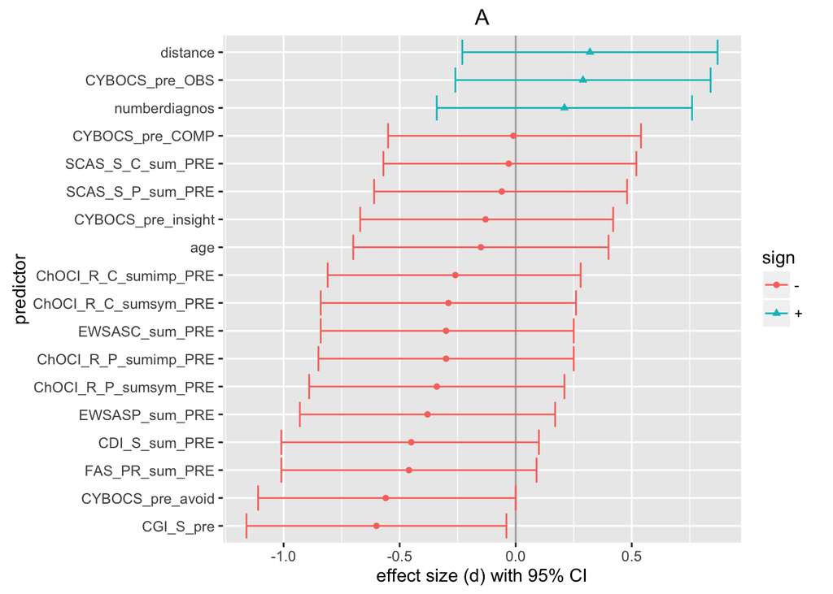

```r
data_class_effsize %>%
  dplyr::select(predictor, d, l.d, u.d) %>%
  mutate(sign = ifelse(d > 0, "+", "-")) -> data_class_effsize_short

data_class_effsize_short %>%
  ggplot(aes(x = reorder(predictor, d), y = d, color = sign)) +
  geom_hline(yintercept = 0, alpha = .4) +
  geom_point(aes(shape = sign)) +
  geom_errorbar(aes(ymin = l.d, ymax = u.d)) +
  coord_flip() +
  ylab("effect size (d) with 95% CI") +
  xlab("predictor") +
  ggtitle("A") -> es_plot_1

es_plot_1
```

A bit more specifically, let’s look at one predictor variable how the groups differ in that variable with regard to effect size (d).

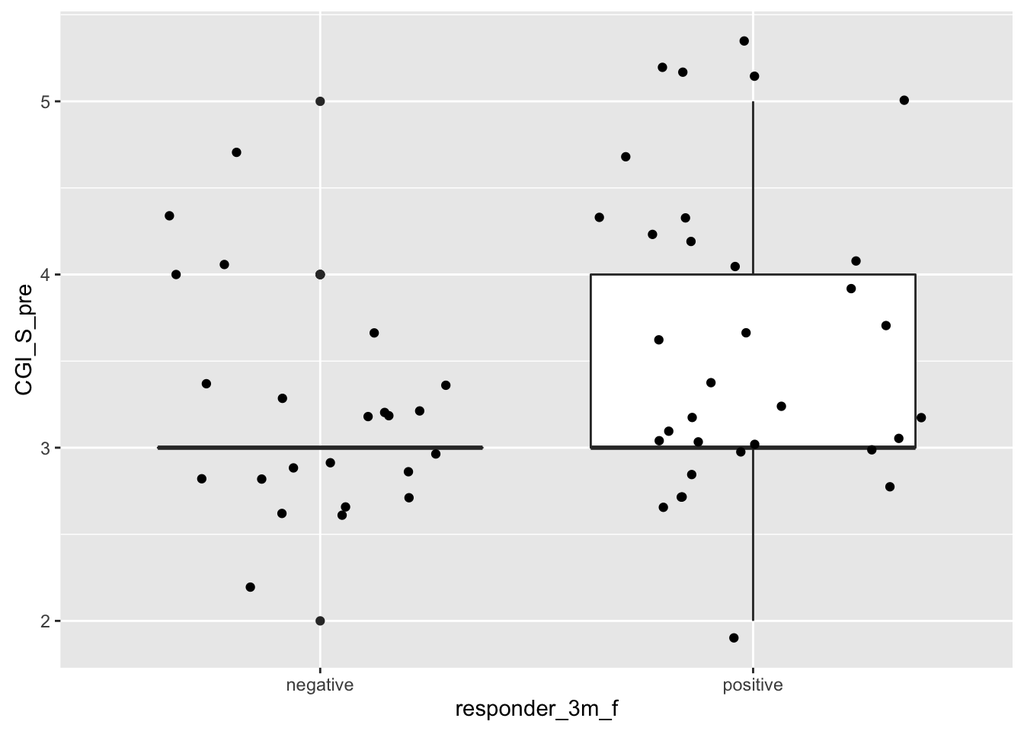

```r
data_class %>%
  dplyr::select(CGI_S_pre, responder_3m_f) %>%
  ggplot(aes(x = responder_3m_f, y = CGI_S_pre)) +
  geom_boxplot() +
  geom_jitter()
```

Hm, does not appear to show a strong difference between the groups.

Much more tangible than d is CLES, that’s the probability than some one of group 1 will have an higher value than a randomly chosen person from group 2. Let’s plot that, but note that it’s a function of d (so no new information).

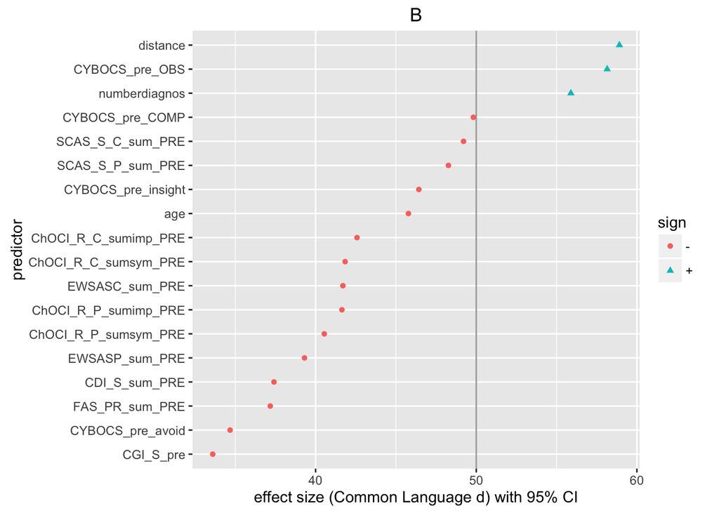

```r
data_class_effsize %>%
  dplyr::select(predictor, cl.d) %>%
  mutate(sign = ifelse(cl.d > 50, "+", "-")) %>%
  ggplot(aes(x = reorder(predictor, cl.d), y = cl.d, color = sign)) +
  geom_hline(yintercept = 50, alpha = .4) +
  geom_point(aes(shape = sign)) +
  coord_flip() +
  ylab("effect size (Common Language d) with 95% CI") +
  xlab("predictor") +
  ggtitle("B") -> es_plot_2

es_plot_2
```

Both plots together:

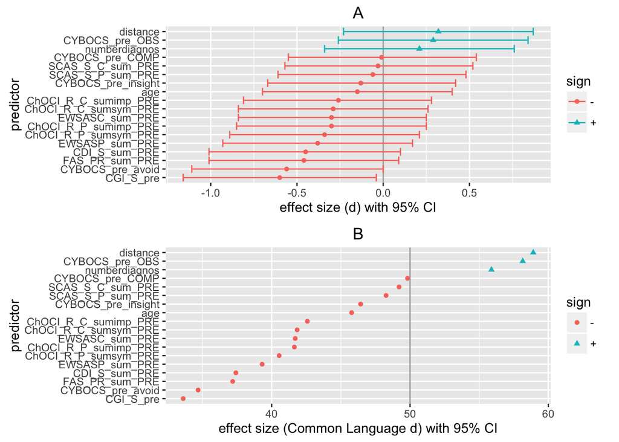

```r
grid.arrange(es_plot_1, es_plot_2)
```

## 5.2 Assocation of predictors with numeric outcome variable `CYBOCS_3m`

Now let’s look at something similar: The association of the (numeric) predictors with the numeric outcome variable

```r
data2 <- read_csv("raw_data/data_mod2.csv")
```

```r
data2 %>%
  select_if(is.numeric) %>%
  correlate %>%
  focus(CYBOCS_3m) %>%
  arrange(desc(abs(CYBOCS_3m))) %>% print(n=32)
```

```
## # A tibble: 32 × 2
##                 rowname    CYBOCS_3m
##                   <chr>        <dbl>
## 1        responder_3m_f -0.754050188
## 2             CGI_S_pre  0.456854966
## 3        EWSASP_sum_PRE  0.433386287
## 4  ChOCI_R_P_sumimp_PRE  0.425027738
## 5         CDI_S_sum_PRE  0.366981120
## 6      SCAS_S_P_sum_PRE  0.354726536
## 7        FAS_PR_sum_PRE  0.325444416
## 8       CYBOCS_pre_COMP  0.319726069
## 9      CYBOCS_pre_avoid  0.316634461
## 10 ChOCI_R_C_sumimp_PRE  0.305719627
## 11                 ADHD  0.286799974
## 12       EWSASC_sum_PRE  0.281058541
```

[output cut: 20 more lines]

Hey, that looks quite promising!

Let’s finally plot it:

```r
data_rect <- data.frame(xmin = -Inf, xmax = Inf, ymin = -.1, ymax = .1)

data2 %>% select_if(is.numeric) %>% dplyr::select(dplyr::contains("CYBOCS_3m"))
```

```
## # A tibble: 56 × 1
##    CYBOCS_3m
##        <int>
## 1         12
## 2         11
## 3          7
## 4          9
## 5          4
## 6          9
## 7         21
## 8         22
## 9          0
## 10        20
## # ... with 46 more rows
```

```
## # A tibble: 32 × 2
##                 rowname    CYBOCS_3m
##                   <chr>        <dbl>
## 1        responder_3m_f -0.754050188
## 2             CGI_S_pre  0.456854966
## 3        EWSASP_sum_PRE  0.433386287
## 4  ChOCI_R_P_sumimp_PRE  0.425027738
## 5         CDI_S_sum_PRE  0.366981120
## 6      SCAS_S_P_sum_PRE  0.354726536
## 7        FAS_PR_sum_PRE  0.325444416
## 8       CYBOCS_pre_COMP  0.319726069
## 9      CYBOCS_pre_avoid  0.316634461
## 10 ChOCI_R_C_sumimp_PRE  0.305719627
## 11                 ADHD  0.286799974
## 12       EWSASC_sum_PRE  0.281058541
```

[output cut: 20 more lines]

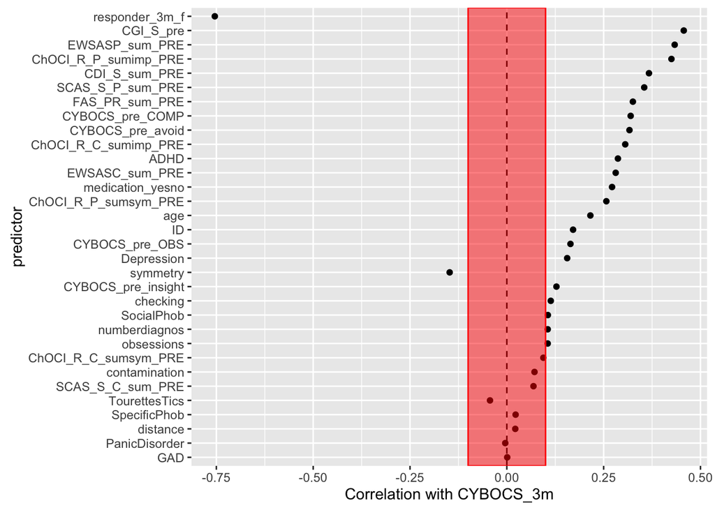

```r
data2 %>%
  select_if(is.numeric) %>%
  correlate  %>%
  focus(CYBOCS_3m) %>%
  arrange(desc(abs(CYBOCS_3m))) %>% print(n=32) %>%
  ggplot(aes(x = reorder(rowname, abs(CYBOCS_3m)), y = CYBOCS_3m)) + geom_point() +
  coord_flip() +
  xlab("predictor") +
  ylab("Correlation with CYBOCS_3m") +
  # ggtitle("Correlations of predictors with outcome (CYBOCS_3m)") +
  geom_hline(yintercept = 0, linetype = "dashed")  +
  geom_rect(data = data_rect,
           aes(ymin = ymin, ymax = ymax, xmin = xmin, xmax = xmax), inherit.aes = FALSE, alpha = .5, fill = "red", color = "red")
```

Don’t forget to save results to disk…

```r
save(mod_results, file = "mod_results.Rda")
```